# Cell-type deconvolution analysis

Author

Prof. Francesca Finotello

# Guided analysis

In this exercise, we will perform cell-type deconvolution of bulk RNA sequencing (RNA-seq) data generated from human blood samples ([Finotello et al. Genome Medicine, 2019](https://link.springer.com/article/10.1186/s13073-019-0638-6)). Blood samples were obtained from healthy donors, and used to create mixtures of peripheral blood mononuclear cells (PBMC) and polymorphonuclear (PMN) cells, which were then subjected to RNA-seq with the [Illumina](https://www.illumina.com/) technology.

## Data access and initialization

Before we begin the analysis, let’s set the seed of the random number generator as indicated below to ensure reproducible plots and results.

```r
set.seed(1234)
```

For the analysis, we will be using immunedeconv, a unified interface to different 1-generation deconvolution tools ([Sturm et al. Bioinformatics, 2019](https://academic.oup.com/bioinformatics/article/35/14/i436/5529146)). We will also use the R-implementation of the [Color Brewer](https://colorbrewer2.org/) palette resource. We can load both packages using the `library` function.

```r
library(immunedeconv)
library(RColorBrewer)
```

Let’s load the gene expression matrix from the Finotello et al. study, which is saved in the `finotello_tpm.rds` file stored in the “Data” directory.

```r
finotello_tpm <- readRDS("../Data/finotello_tpm.rds")
```

**Warning**

The path to “Data” assumes a specific folder structure. Adjust it to match the location of the “Data” folder on your system (e.g., “/gpfs/gpfs1/scratch/c9881023/shared/Data”).

The matrix contains transcripts per million (TPM)-normalized values for 19,423 genes and 9 samples.

```r
dim(finotello_tpm)
```

```
[1] 19423     9
```

```r
head(finotello_tpm)
```

```
             pbmc_1   pbmc_10   pbmc_12     pbmc_2    pbmc_4   pbmc_5 pbmc_6
UBE2Q2P2   0.000000 0.0811149 0.0000000 0.00000000 0.0596913 0.613015      0
SSX9       0.000000 0.0000000 0.0000000 0.00000000 0.2125650 0.000000      0
CXorf67    0.118865 0.0867824 0.1884640 0.09400570 0.4967050 0.196090      0
EFCAB8     0.000000 0.0000000 0.0315701 0.00449917 0.3464000 0.385828      0
SPATA31B1P 0.000000 0.0000000 0.0000000 0.00000000 0.0000000 0.000000      0
SDR16C6P   0.000000 0.0000000 0.0000000 0.00000000 0.2878810 0.000000      0
              pbmc_7    pbmc_9
UBE2Q2P2   0.0000000 0.0000000
SSX9       0.0000000 0.0000000
CXorf67    0.1654060 0.1579260
EFCAB8     0.0481871 0.0415714
SPATA31B1P 0.0000000 0.0000000
SDR16C6P   0.0000000 0.0000000
```

## Quantification of cell-type abundance scores

Via immunedeconv, we can run bulk RNA-seq data cell-type quantification using multiple tools. Let’s try first a very quick scoring method (gene-set-based) called MCP-counter ([Becht et al. Genome Biology, 2016](https://link.springer.com/article/10.1186/s13059-016-1070-5)). We can perform this analysis very quickly using the `deconvolute_mcp_counter` function from immunedeconv, and save the results in an object called `finotello_mcp`.

```r
finotello_mcp <- deconvolute_mcp_counter(finotello_tpm)
```

Let’s inspect the result matrix, which has cell types in rows and samples in columns, to see which cell types were quantified. If we then sum the quantification values across all cell types for a given sample, we notice that they do not add up to 1 (100%). This is because these values are adimensional scores, not actual cell fractions.

```r
dim(finotello_mcp)
```

```
[1] 10  9
```

```r
head(finotello_mcp)
```

```
                          pbmc_1   pbmc_10   pbmc_12     pbmc_2     pbmc_4
T cells                79.315446 60.490311  65.98208  66.324201  71.230100
CD8 T cells           106.321386 89.006210 168.40927  88.025720 100.052650
Cytotoxic lymphocytes  89.695454 61.122502 246.75242 128.593685 299.876107
B lineage              43.786304 47.368458  32.25088  22.126284  35.660174
NK cells                7.994815  4.679072  11.35416   5.764754   9.458455
Monocytic lineage      27.266925 30.383338  31.37624  17.736759  37.154857
                          pbmc_5     pbmc_6    pbmc_7    pbmc_9
T cells                54.667586  59.270497  63.35133  49.75932
CD8 T cells           123.308600 140.334971 175.33851  74.21031
Cytotoxic lymphocytes 326.734681 198.619946 229.20441 240.90007
B lineage              45.449043  39.788724  23.96717  21.69973
NK cells                8.782401   6.799939  16.80822  11.72434
Monocytic lineage      47.346683  31.782763  26.86322  31.17012
```

```r
rownames(finotello_mcp)
```

```
 [1] "T cells"                 "CD8 T cells"
 [3] "Cytotoxic lymphocytes"   "B lineage"
 [5] "NK cells"                "Monocytic lineage"
 [7] "Myeloid dendritic cells" "Neutrophils"
 [9] "Endothelial cells"       "Fibroblasts"
```

```r
apply(finotello_mcp, 2, sum)
```

```
  pbmc_1  pbmc_10  pbmc_12   pbmc_2   pbmc_4   pbmc_5   pbmc_6   pbmc_7
382.5559 316.4331 577.6107 356.1311 608.9128 655.8574 513.2421 567.3033
  pbmc_9
460.2174
```

We can now select a certain cell type and visualize with a barplot its abundance *score* across the various samples. For instance, we can focus on the neutrophils:

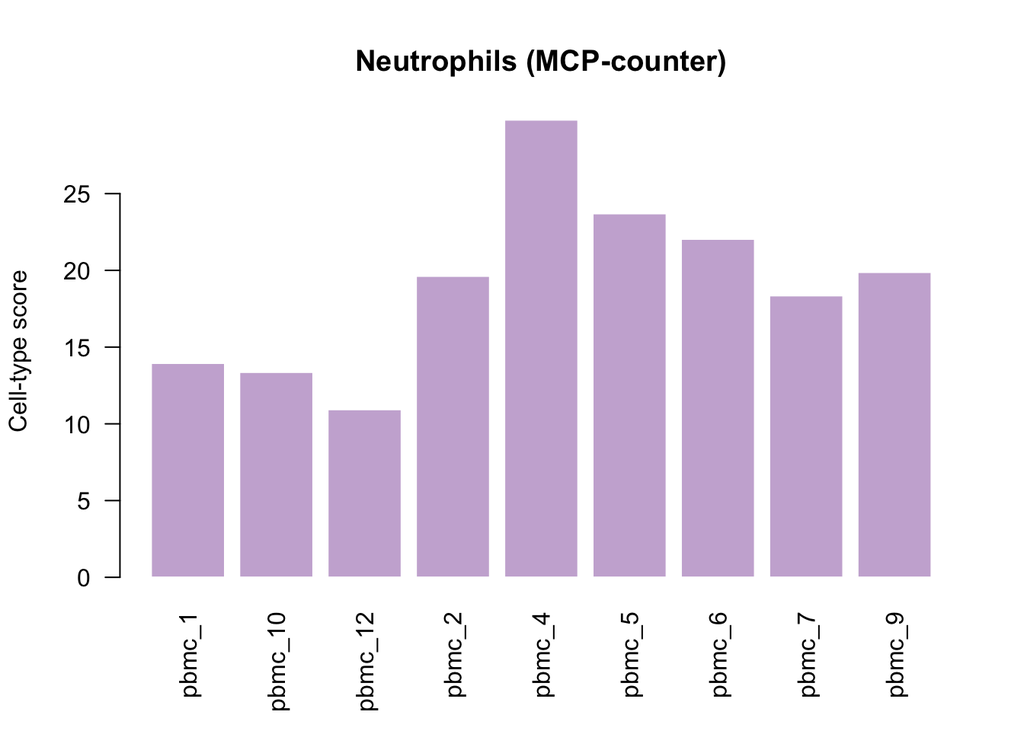

```r
celltype <- "Neutrophils"
barplot(finotello_mcp[celltype,],
        main = paste(celltype, "(MCP-counter)"),
        las = 2,
        ylab = "Cell-type score",
        col = "#cab2d6",
        border = FALSE)
```

We can see that sample “pbmc_4” is the one with the highest estimated abundance of neutrophils.

❓ **Question:** How can we visualize the abundance score for CD8+ T cells, and what is the sample with the highest score?

**Click to see the answer**

**Answer:**

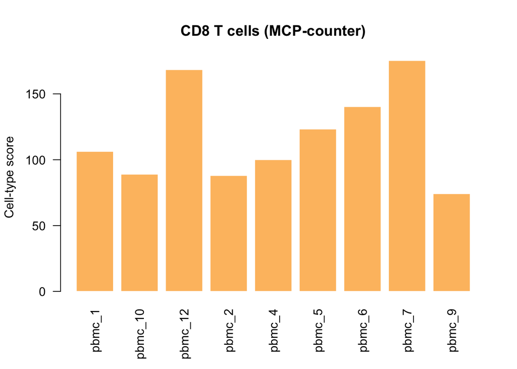

```r
celltype <- "CD8 T cells"
barplot(finotello_mcp[celltype,],
        main = paste(celltype, "(MCP-counter)"),
        las = 2,
        ylab = "Cell-type score",
        col = "#fdbf6f",
        border = FALSE)
```

```r
which.max(finotello_mcp[celltype,])
```

```
pbmc_7
     8
```

## Deconvolution of cell fractions

We want now to test on the same dataset a deconvolution method, rather than a scoring one. We will focus on quanTIseq ([Finotello et al. Genome Medicine, 2019](https://link.springer.com/article/10.1186/s13073-019-0638-6)), which we can run through the `deconvolute_quantiseq` function in immunedeconv. Besides providing the object with the TPM values, we need to specify that the data come from an RNA-seq experiment and not microarrays (`arrays = FALSE`), it is from blood and not tumor samples (`tumor = FALSE`), and we want to apply a correction for mRNA abundance bias (`scale_mrna = TRUE`).

```r
finotello_quanTIseq <- deconvolute_quantiseq(finotello_tpm,
                                             arrays = FALSE,
                                             tumor = FALSE,
                                             scale_mrna = TRUE)
```

As before, we can check the object of results, and verify that, this time, cell fractions sum up to 100% in every sample.

```r
dim(finotello_quanTIseq)
```

```
[1] 11  9
```

```r
head(finotello_quanTIseq)
```

```
                   pbmc_1     pbmc_10      pbmc_12     pbmc_2      pbmc_4
B.cells        0.09287349 0.094897799 0.0643340592 0.04713111 0.070890822
Macrophages.M1 0.00000000 0.000000000 0.0006052232 0.00000000 0.000000000
Macrophages.M2 0.01818604 0.011286071 0.0121268219 0.01719900 0.002274707
Monocytes      0.17499726 0.215400901 0.1147227006 0.15202843 0.134391932
Neutrophils    0.02745332 0.033619952 0.0221939769 0.05456784 0.010979511
NK.cells       0.02084551 0.002609008 0.0557982363 0.02320010 0.103056802
                    pbmc_5     pbmc_6     pbmc_7     pbmc_9
B.cells        0.084025396 0.08557949 0.04752380 0.04526941
Macrophages.M1 0.000000000 0.00000000 0.00000000 0.00000000
Macrophages.M2 0.007583426 0.02023263 0.02172621 0.01909005
Monocytes      0.233726882 0.22019516 0.17361407 0.19574637
Neutrophils    0.014159003 0.05781820 0.04178430 0.04602081
NK.cells       0.079140964 0.01758285 0.07383224 0.05384687
```

```r
apply(finotello_quanTIseq, 2, sum)
```

```
 pbmc_1 pbmc_10 pbmc_12  pbmc_2  pbmc_4  pbmc_5  pbmc_6  pbmc_7  pbmc_9
      1       1       1       1       1       1       1       1       1
```

quanTIseq estimated ten different immune cell types, plus the percentage of *unknown content* (called `Other` in the result matrix), accounting for the expression of cell types and programs that are not represented in the signature matrix:

```r
rownames(finotello_quanTIseq)
```

```
 [1] "B.cells"         "Macrophages.M1"  "Macrophages.M2"  "Monocytes"
 [5] "Neutrophils"     "NK.cells"        "T.cells.CD4"     "T.cells.CD8"
 [9] "Tregs"           "Dendritic.cells" "Other"
```

Before proceeding with the plots, let’s use RColorBrewer to generate a palette with 12 different colors that we can use to distinguish the verious cell types in our visualizations:

```r
pal_12 <- brewer.pal(12, "Set3")
```

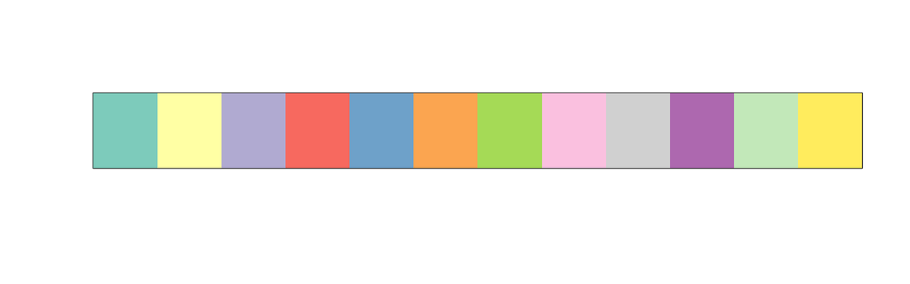

To visualize the composition of every sample, we can use a *stacked barplot* created by applying the `barplot` function to the results object `finotello_quanTIseq`. The `las = 2` parmeter settings, which can be used in various plotting functions, is specified to arrange the sample names vertically, so they fit in the limited space available along the x-axis.

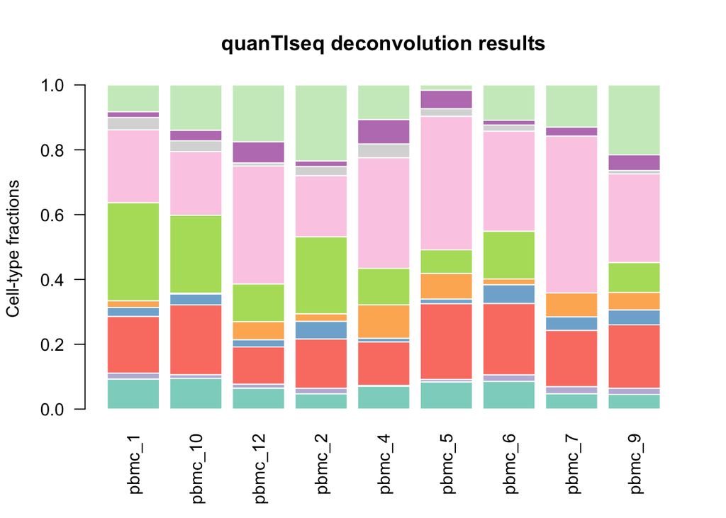

```r
barplot(finotello_quanTIseq,
        col = pal_12,
        ylab = "Cell-type fractions",
        las = 2,
        main = "quanTIseq deconvolution results",
        border = FALSE)
```

To interpret the results, we need to add a legend to associate every color to the corresponding cell type.

In the code below, `par(mar = c(5, 4, 4, 10))` increases the right margin to make room for the legend. Then, in the legend function, `xpd = TRUE` allows drawing outside the plot area, and `inset = -0.3` moves the legend into that extra space on the right.

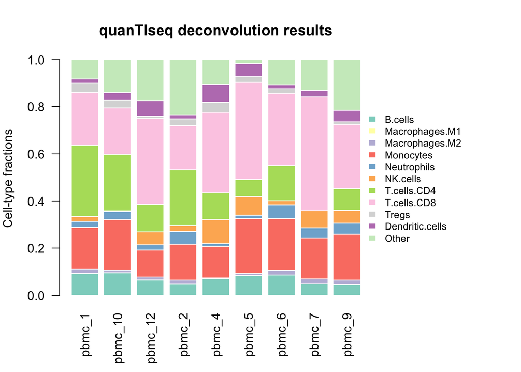

```r
par(mar = c(5, 4, 4, 10))

barplot(finotello_quanTIseq,
        col = pal_12,
        ylab = "Cell-type fractions",
        las = 2,
        main = "quanTIseq deconvolution results",
        border = FALSE)

legend("right",
       legend = rownames(finotello_quanTIseq),
       fill = pal_12,
       cex = 0.8,
       bty = "n",
       border = FALSE,
       xpd = TRUE,
       inset = -0.3)
```

**Note:**: Stacked barplots are extremely informative for *deconvolution* methods that infer *cell fractions* that can be interpreted as such, providing a quantitative overview of the cellular composition of every sample. Such a plot would not be informative nor meaningful for *scoring* methods, like MCP-counter, which returns *adimensional scores* that cannot be compared across cell types:

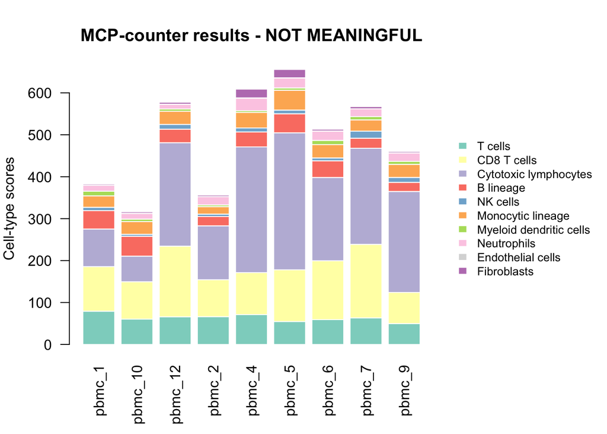

```r
par(mar = c(5, 4, 4, 10))

barplot(finotello_mcp,
        col = pal_12,
        ylab = "Cell-type scores",
        las = 2,
        main = "MCP-counter results - NOT MEANINGFUL",
        border = FALSE)

legend("right",
       legend = rownames(finotello_mcp),
       fill = pal_12,
       cex = 0.8,
       bty = "n",
       border = FALSE,
       xpd = TRUE,
       inset = -0.45)
```

## Methods comparison

Let’s make a scatterplot to compare the agreement between MCP-counter and quanTIseq on their quantification of CD8+ T cells (called `Cytotoxic lymphocytes` by MCP-counter). We can also evaluate their agreement in terms of Pearson’s correlation, which we can add to the plot using `text`:

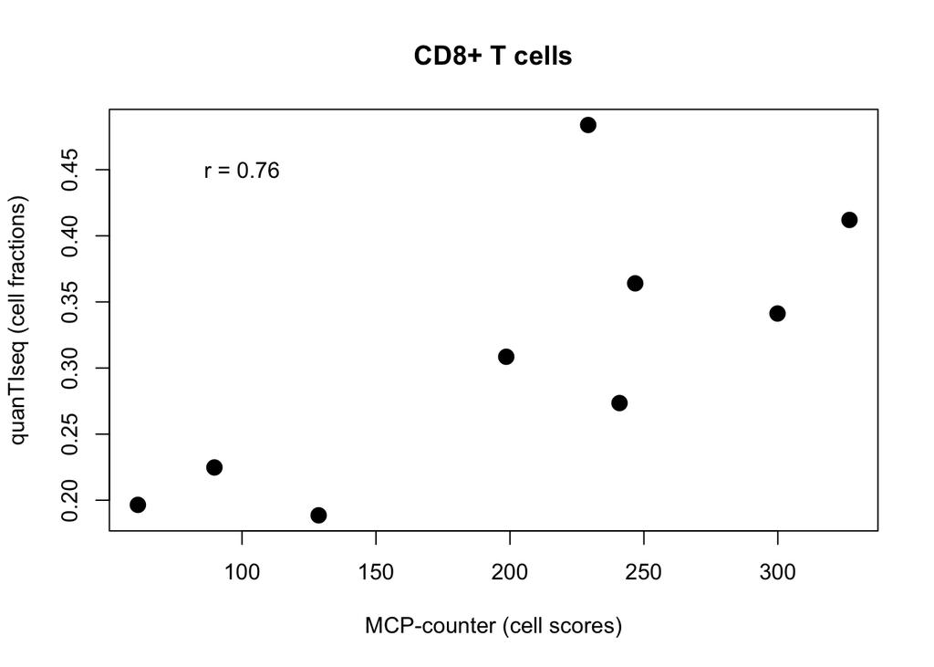

```r
cd8_mpc <- finotello_mcp["Cytotoxic lymphocytes", ]
cd8_qts <- finotello_quanTIseq["T.cells.CD8", ]

plot(cd8_mpc, cd8_qts,
     xlab = "MCP-counter (cell scores)",
     ylab = "quanTIseq (cell fractions)",
     pch = 19,
     cex = 1.5,
     main = "CD8+ T cells")

r_cd8 <- round(cor(cd8_mpc, cd8_qts), digits = 2)

text(100, 0.45, labels = paste("r =", r_cd8))
```

❓ **Question:** What is the agreement of these two methods on the quantification of neutrophils?

**Click to see the answer**

**Answer:**

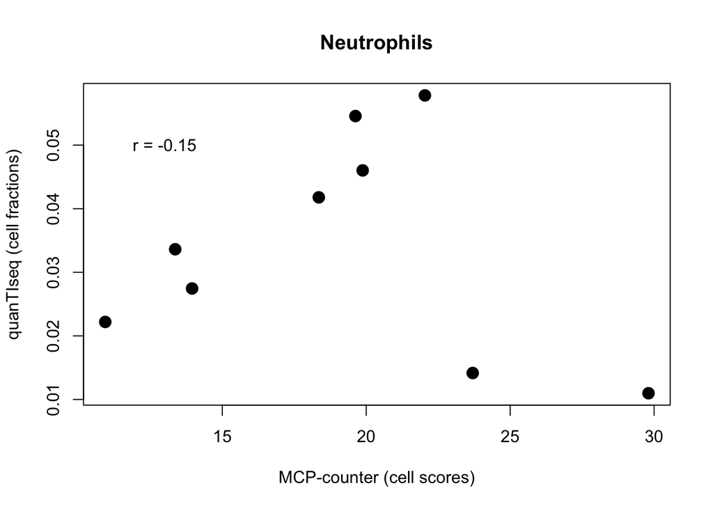

```r
neu_mpc <- finotello_mcp["Neutrophils", ]
neu_qts <- finotello_quanTIseq["Neutrophils", ]

plot(neu_mpc, neu_qts,
     xlab = "MCP-counter (cell scores)",
     ylab = "quanTIseq (cell fractions)",
     pch = 19,
     cex = 1.5,
     main = "Neutrophils")

r_neu <- round(cor(neu_mpc, neu_qts), digits = 2)

text(13, 0.05, labels = paste("r =", r_neu))
```

## Validation of deconvolution results

For this experiment, we also have some ground truth cell fractions obtained via fluorescence-activated cell sorting (FACS) of the same samples, which we can use to validate deconvolution results. We can load them with `readRDS`:

```r
finotello_truth <- readRDS("../Data/finotello_facs.rds")
```

**Warning**

The path to “Data” assumes a specific folder structure. Adjust it to match the location of the “Data” folder on your system (e.g., “/gpfs/gpfs1/scratch/c9881023/shared/Data”).

```r
dim(finotello_truth)
```

```
[1] 9 9
```

```r
head(finotello_truth)
```

```
            pbmc_1 pbmc_10 pbmc_12 pbmc_2 pbmc_4 pbmc_5 pbmc_6 pbmc_7 pbmc_9
B.cells     0.0581  0.0640  0.0516 0.0296 0.0384 0.0606 0.0645 0.0403 0.0480
Monocytes   0.2001  0.3586  0.2003 0.2481 0.1943 0.2636 0.3238 0.2387 0.2815
Neutrophils 0.0245  0.0397  0.0268 0.0484 0.0367 0.0332 0.0443 0.0505 0.0257
NK.cells    0.0675  0.0718  0.1409 0.1128 0.1154 0.0896 0.1035 0.1746 0.1144
T.cells.CD4 0.3796  0.1786  0.1533 0.2552 0.2247 0.0853 0.0996 0.1274 0.1289
T.cells.CD8 0.1564  0.1839  0.2984 0.1638 0.2452 0.3661 0.2834 0.3227 0.2260
```

```r
rownames(finotello_truth)
```

```
[1] "B.cells"         "Monocytes"       "Neutrophils"     "NK.cells"
[5] "T.cells.CD4"     "T.cells.CD8"     "Tregs"           "Dendritic.cells"
[9] "Other"
```

Before we compare deconvolution results from quanTIseq with the ground truth, let’s identify which samples (`csamples`) and cell types (`ccells`) are in common between the two:

```r
ccells <- intersect(rownames(finotello_quanTIseq),
                    rownames(finotello_truth))
csamples <- intersect(colnames(finotello_quanTIseq),
                      colnames(finotello_truth))
```

We can now save in two new objects a reduced version of the original matrix of deconvolution results (`finotello_quanTIseq_sel`) and ground-truth cell fractions (`finotello_truth_sel`), including only the cell types and samples that are in common. This way, we also make sure that they appear in the same order in the two matrices, e.g., sample “pbmc_4” is always on the 5th column, and neutrophils are on the 3rd row of both objects.

```r
finotello_quanTIseq_sel <- finotello_quanTIseq[ccells, csamples]
finotello_truth_sel <- finotello_truth[ccells, csamples]
colnames(finotello_quanTIseq_sel)[5]
```

```
[1] "pbmc_4"
```

```r
colnames(finotello_truth_sel)[5]
```

```
[1] "pbmc_4"
```

```r
rownames(finotello_quanTIseq_sel)[3]
```

```
[1] "Neutrophils"
```

```r
rownames(finotello_truth_sel)[3]
```

```
[1] "Neutrophils"
```

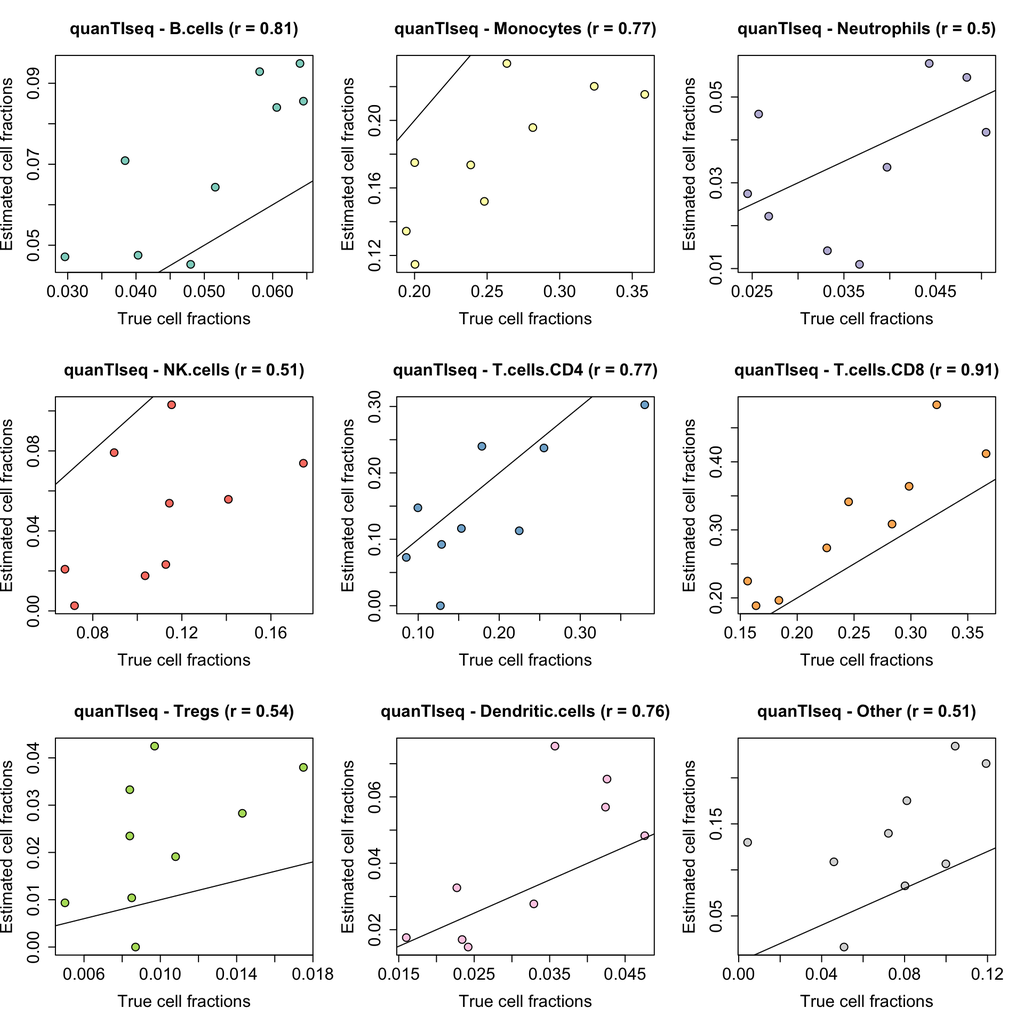

❓ **Question:** How would you consider the deconvolution performance for CD8+ T cells? And for regulatory T cells (Tregs)?

We can also visualize all cell types in a single scatter plot, using a different color for each cell type.

To do this, we first transform each cell-type-by-sample matrix (from the deconvolution and FACS results) into a single numeric vector by concatenating all its entries. In this way, the values from all samples and all cell types are placed one after another in the same order in both vectors. Each position in the two vectors therefore still refers to the same sample–cell-type combination.

Next, we create a label vector that records which cell type each entry belongs to. This is done by repeating each row name (that is, each cell type) for all samples. Finally, we use these labels to assign a color to every entry, so that all points belonging to the same cell type are displayed with the same color.

```r
finotello_truth_sel_v <- as.numeric(as.matrix(finotello_truth_sel))
finotello_quanTIseq_sel_v <- as.numeric(as.matrix(finotello_quanTIseq_sel))
labels <- rep(rownames(finotello_truth_sel),
              times = ncol(finotello_truth_sel))
colors <- pal_12[as.factor(labels)]
```

We can estimate Pearson’s correlation for all cell types altogether, using these vectors:

```r
r <- round(cor(finotello_truth_sel_v,
               finotello_quanTIseq_sel_v),
           digits = 2)
```

And we can now make the final plot:

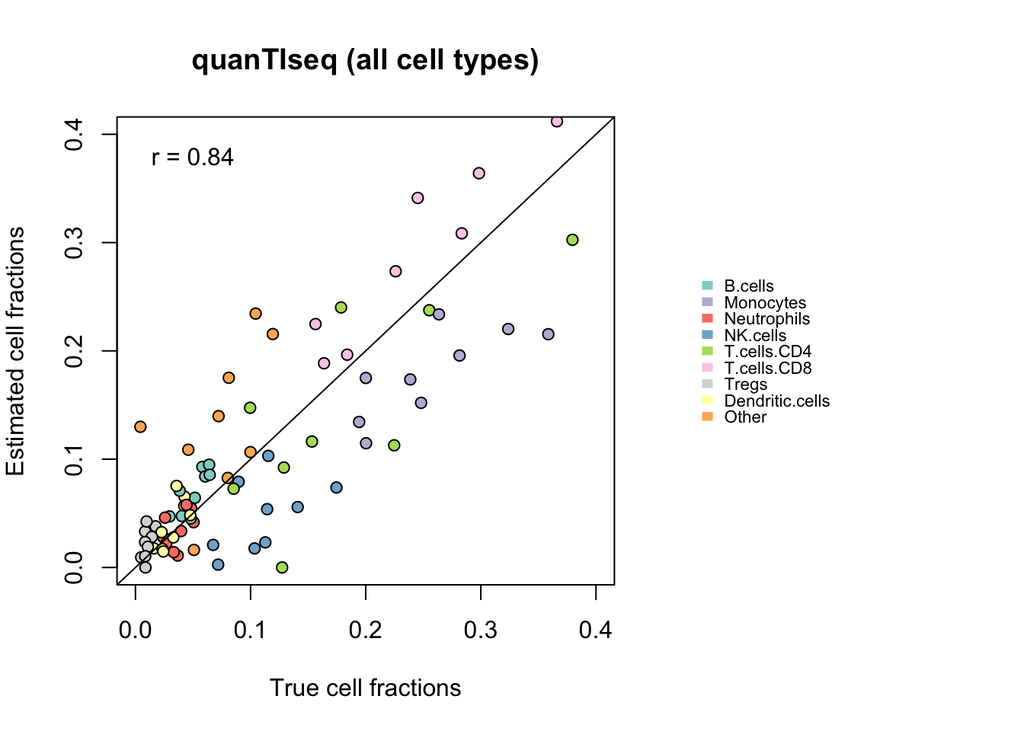

```r
par(mar = c(5, 4, 4, 14))

plot(finotello_truth_sel_v,
     finotello_quanTIseq_sel_v,
     xlab = "True cell fractions",
     ylab = "Estimated cell fractions",
     main = "quanTIseq (all cell types)",
     xlim = c(0, 0.4),
     ylim = c(0, 0.4),
     pch = 21,
     col = "black",
     bg = colors)

abline(0, 1)
text(0.05, 0.38, paste0("r = ", r))

legend("right",
       legend = unique(labels),
       fill = unique(colors),
       cex = 0.7,
       y.intersp = 0.8,
       x.intersp = 0.7,
       bty = "n",
       border = FALSE,
       xpd = TRUE,
       inset = -0.45)
```

❓ **Question:** Can you spot some cell types that are systematically over- or under-estimated?

# Homework

In this exercise, we will perform deconvolution analysis of a second bulk RNA-seq dataset, generated from human PBMC ([Hoek et al. Plos ONE, 2015](https://doi.org/10.1371/journal.pone.0118528)).

We can load, from the “Data” folder, the gene expression matrix (TPM-normalized), as well as the FACS-derived ground-truth cell fractions for 5 cell types

```r
hoek_tpm <- readRDS("../Data/hoek_tpm.rds")
hoek_truth <- readRDS("../Data/hoek_facs.rds")
rownames(hoek_truth)
```

```
[1] "T cell"    "Monocytes" "B cells"   "mDC"       "NK cells"
```

**Warning**

The path to “Data” assumes a specific folder structure. Adjust it to match the location of the “Data” folder on your system (e.g., “/gpfs/gpfs1/scratch/c9881023/shared/Data”).

In this analysis, we will use another deconvolution method called EPIC ([Racle et al. eLife 2017](https://elifesciences.org/articles/26476)). We can run EPIC using the `deconvolute_epic` function of immunedeconv. Also for this method, we need to specify `tumor = FALSE` and `scale_mrna = TRUE` in the parameter settings. Applied to this dataset with these settings, EPIC will quantify the following cell types:

```
[1] "Bcells"      "CD4_Tcells"  "CD8_Tcells"  "Monocytes"   "Neutrophils"
[6] "NKcells"     "otherCells"
```

As you notice by comparing the cell names to the ground truth ones, some can be directly compared, like `Monocytes`, while some, like `Bcells` and `NKcells`, need to be renamed in the object of deconvolution results to match the FACS ground truth (i.e., `B cells` and `NK cells`), e.g.:

```r
idx <- which(rownames(hoek_epic) == "Bcells")
rownames(hoek_epic)[idx] <- "B cells" # Add a space to match FACS results
```

Moreover, we need to add a new row for the quantification of `T cell`, calculated as the sum of `CD4_Tcells` and `CD8_Tcells`, to be able to compare it to the ground-truth data:

```r
hoek_epic <- rbind(
  hoek_epic,
  "T cell" = hoek_epic["CD4_Tcells", ] + hoek_epic["CD8_Tcells", ]
)
```

Check carefully the cell types present in the `hoek_epic` and `hoek_truth` objects, and adapt the former accordingly. After that, proceed with an analysis similar to that presented in the guided exercise, putting a special focus on the visualization of the per-sample cellular composition, and on the agreement of deconvolution results with the ground-truth cell fractions.